# 9week_theory_2

김현우,박주연,이주영,이지예,주진영,홍정아

2018년 5월 30일

# Overview

The training data set for the Rossman Store Sales consists of sales data for a set of 1115 stores across 942 days. If we multiply those two numbers together we would would expect to find a data set with 1050330 observations, however, there are in fact only 1017209 observations in the training set.

If we load the training data and plot the number of stores reporting data for each date in the training time series, we can see that there is a 6 month gap where we have a smaller number of stores reporting sales revenue. In the description of the data set it was said that “some stores were temporarily closed for refurbishment” so we can attribute the missing data to the stores being closed within this 6 month period.

The problem with this gap in the data is that it makes it difficult to use the *forecast* package as the methods in that package don’t deal well with gaps in the time series. This leaves us with two choices: either to artificially make the gap disappear and make a continuous time series with available data points or to impute sales figures during the renovation period to have a complete time series of 942 days as with other stores that did not undergo renovation. This markdown file is looking at this second approach.

```r
train <- read_csv("train.csv", col_types=list(
  Store = col_integer(),
  DayOfWeek= col_integer(),
  Date = col_date(),
  Sales = col_integer(),
  Customers = col_integer(),
  Open = col_integer(),
  Promo = col_integer(),
  StateHoliday = col_character(),
  SchoolHoliday = col_integer()))
```

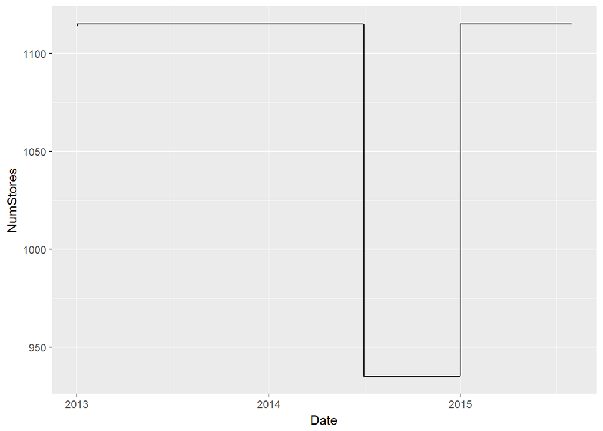

```r
by_Date <- train %>% group_by(Date) %>% summarise(NumStores=n())
ggplot(by_Date, aes(Date,NumStores)) + geom_line()
```

From the above figure, we can see that the gap occurs at the beginning of July 2014 and runs until the end of the year. To confirm the actual dates of the beginning and end we can look at the data around the beginning and end of this period.

```r
by_Date_Gap <- by_Date[by_Date$Date %in%
                         seq(as.Date("2014-06-30"),as.Date("2015-01-01"),by="day"),]
head(by_Date_Gap,3)
```

```
## # A tibble: 3 x 2
##   Date       NumStores
##   <date>         <int>
## 1 2014-06-30      1115
## 2 2014-07-01       935
## 3 2014-07-02       935
```

```r
tail(by_Date_Gap,3)
```

```
## # A tibble: 3 x 2
##   Date       NumStores
##   <date>         <int>
## 1 2014-12-30       935
## 2 2014-12-31       935
## 3 2015-01-01      1115
```

# Identifying the Stores with Missing Data

If we look at stores reporting sales at the beginning of the gap on *2014-7-1* and subtract this from the list of all stores, we can find which stores have missing data.

```r
all_stores <- unique(train$Store)
stores_reporting <- train$Store[train$Date == as.Date("2014-7-1")]
missing_stores <- all_stores[!(all_stores %in% stores_reporting)]
missing_stores
```

```
##   [1]   13   20   22   32   36   41   46   51   52   58   72   76   81   89
##  [15]   99  100  108  113  115  127  129  132  136  137  139  144  145  149
##  [29]  155  159  164  165  172  174  181  183  186  190  191  192  204  215
##  [43]  218  231  243  258  263  275  277  279  283  284  287  288  298  306
##  [57]  317  342  345  348  365  385  399  407  412  413  420  427  428  429
##  [71]  430  434  457  471  477  485  490  492  498  500  501  512  514  518
##  [85]  522  534  539  540  542  547  555  571  573  575  587  598  604  611
##  [99]  612  619  620  629  633  636  637  638  644  646  650  660  669  670
## [113]  671  677  684  694  701  702  706  710  711  712  716  719  736  739
## [127]  744  750  766  771  775  778  797  804  805  806  815  820  825  842
## [141]  851  858  859  879  884  890  893  900  902  903  904  909  915  919
## [155]  920  932  941  952  974  977  989 1000 1004 1009 1012 1019 1027 1038
## [169] 1041 1049 1056 1065 1067 1080 1092 1094 1102 1104 1107 1109
```

Picking the first store in the list, Store 13, and plotting the data over time, we can clearly see the gap in the time series.

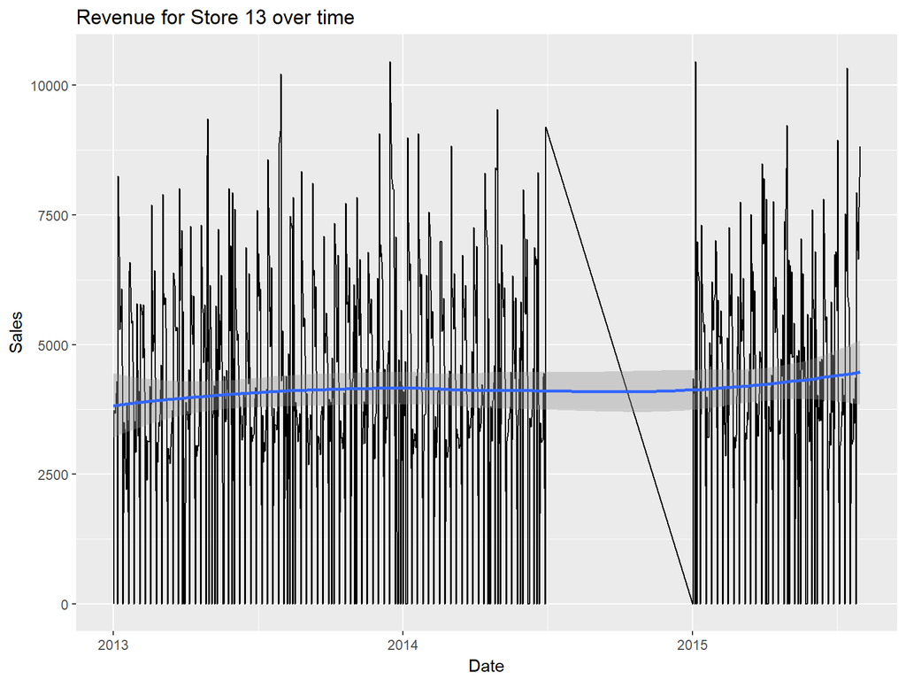

```r
store13 <- subset(train, Store==13)
ggplot(store13, aes(Date,Sales)) +
  geom_line() +
  geom_smooth() +
  ggtitle("Revenue for Store 13 over time")
```

Given our above list of stores with missing data, we want to confirm if this list is constant over the period of the gap. The simples strategy is to create a new list for each additional day in the period and check the set difference with our original list. If the difference is always zero, then we have a constant list of stores with missing data.

```r
for (date in seq(as.Date("2014-7-2"),as.Date("2014-12-31"),by="day")) {
  stores_reporting <- train$Store[train$Date == date]
  missing_on_date <- all_stores[!(all_stores %in% stores_reporting)]
  if (length(setdiff(missing_on_date,missing_stores)) > 0) {
    cat("Date:",date," Difference in missing stores",setdiff(missing_on_date,missing_stores))
  }
}
```

So far we have identified a gap of six months of missing data for 180 stores, however, there is one other missing data point. If you look closely at the original plot of the number of stores reporting sales versus time, you will see a small down turn at the very beginning. We can confirm this by checking if there are any missing stores on the first day of the time series.

```r
stores_reporting <- train$Store[train$Date == as.Date("2013-1-1")]
additional_missing_store <- all_stores[!(all_stores %in% stores_reporting)]
additional_missing_store
```

```
## [1] 988
```

So only one store is missing data and given that itis New Year’s day, we could create a single row for this store with zeros for Sales, Customers, etc. Alternatively, we can use a majority vote to basically say that this store follows the same pattern as majority of other stores on that day. Since this approach of using a majority vote will be used later to impute part of the missing data in the large 6 month gap we have found, we will use it here as well. Once we have the missing row, we bind it to the initial training set and continue with this.

```r
date <- as.Date("2013-1-1")
day_of_week <- unique(train$DayOfWeek[train$Date == date])
sales <- as.numeric(names(which.max(table(train$Sales[train$Date == date]))))
customers <- as.numeric(names(which.max(table(train$Customers[train$Date == date]))))
open <- as.numeric(names(which.max(table(train$Open[train$Date == date]))))
promo <- as.numeric(names(which.max(table(train$Promo[train$Date == date]))))
state_holiday <- names(which.max(table(train$StateHoliday[train$Date == date])))
school_holiday <- as.numeric(names(which.max(table(train$SchoolHoliday[train$Date == date]))))

missing_row <- data.frame(Store = additional_missing_store,
                          DayOfWeek = day_of_week,
                          Date = date,
                          Sales = sales,
                          Customers = customers,
                          Open = open,
                          Promo = promo,
                          StateHoliday = state_holiday,
                          SchoolHoliday = school_holiday)

train <- rbind(train,missing_row)
```

# Imputing Missing Values

So we have a list of stores and the dates for which we are missing data. We now want to construct a data frame for the missing data and insert it into the existing training data set.

As has been observed elsewhere, due to the large variations in the sales data, we can generally get better results working with the log of the sales values and then converting back for the final submission. For this reason we will add an extra column with the log of the sales values and impute values for stores in our missing data set.

```r
train$logSales <- log(train$Sales+1)
```

The first step will be to construct an empty data frame of the size we require to impute our missing data. One item that we can fill in right away is the Date column. We essentially need to repeat the dates for the days in the gap by the number of stores for which we are missing data.

```r
gap <- seq(as.Date("2014-7-1"),as.Date("2014-12-31"),by="day")
n_missing <- length(gap)*length(missing_stores)
missing_df <- data.frame(Store = integer(n_missing),
                         DayOfWeek = integer(n_missing),
                         Date = rep(gap,length(missing_stores)),
                         Sales = integer(n_missing),
                         Customers = integer(n_missing),
                         Open = integer(n_missing),
                         Promo = integer(n_missing),
                         StateHoliday = character(n_missing),
                         SchoolHoliday = integer(n_missing),
                         logSales = numeric(n_missing),
                         stringsAsFactors=FALSE)
```

We are mainily interested in imputing values for the Sales and Customer columns but there are also other indicators that need to be added such as whether the store is Open, whether a Promo is on, state and school holidays. For each of these latter indicators, we will use a majority vote to impute values for the missing data. In other words, if the majority of stores are open we will assume that this store is open, if the majority of stores are having a promo we will assume this store is having a promo, etc.

```r
for (date in gap) {
  missing_df$Store[missing_df$Date == date] <- missing_stores

  day_of_week <- unique(train$DayOfWeek[train$Date == date])
  missing_df$DayOfWeek[missing_df$Date == date] <- rep(day_of_week, length(missing_stores))

  missing_df$Sales[missing_df$Date == date] <- rep(NA, length(missing_stores))

  missing_df$Customers[missing_df$Date == date] <- rep(NA, length(missing_stores))

  open <- as.numeric(names(which.max(table(train$Open[train$Date == date]))))
  missing_df$Open[missing_df$Date == date] <- rep(open, length(missing_stores))

  promo <- as.numeric(names(which.max(table(train$Promo[train$Date == date]))))
  missing_df$Promo[missing_df$Date == date] <- rep(promo, length(missing_stores))

  state_holiday <- names(which.max(table(train$StateHoliday[train$Date == date])))
  missing_df$StateHoliday[missing_df$Date == date] <- rep(state_holiday, length(missing_stores))

  school_holiday <- as.numeric(names(which.max(table(train$SchoolHoliday[train$Date == date]))))
  missing_df$SchoolHoliday[missing_df$Date == date] <- rep(school_holiday, length(missing_stores))

  missing_df$logSales[missing_df$Date == date] <- rep(NA, length(missing_stores))

}

head(missing_df)
```

```
##   Store DayOfWeek       Date Sales Customers Open Promo StateHoliday
## 1    13         2 2014-07-01    NA        NA    1     1            0
## 2    13         3 2014-07-02    NA        NA    1     1            0
## 3    13         4 2014-07-03    NA        NA    1     1            0
## 4    13         5 2014-07-04    NA        NA    1     1            0
## 5    13         6 2014-07-05    NA        NA    1     0            0
## 6    13         7 2014-07-06    NA        NA    0     0            0
##   SchoolHoliday logSales
## 1             0       NA
## 2             0       NA
## 3             0       NA
## 4             0       NA
## 5             0       NA
## 6             0       NA
```

Now that we have our data frame for the missing store data, we will bind this to existing training set and re-order everything according to date.

```r
train_filled_gap <- rbind(train,missing_df)
train_filled_gap <- train_filled_gap[order(train_filled_gap$Date),]
```

Finally, using the existing Sales, Customer and logSales values we can impute values for the missing time period. To do this we will use the median of existing Sales and Customer data but contrained to the day of the week, whether a promo is running or not, and obviously whether the store is open or not.

```r
train_filled_gap <- train_filled_gap %>%
                      group_by(Store, DayOfWeek, Open, Promo) %>%
                      mutate(Sales = as.integer(ifelse(is.na(Sales),
                                                       ifelse(Open == 0,
                                                              0,
                                                              median(Sales, na.rm=T)),
                                                       Sales))) %>%
                      mutate(Customers = as.integer(ifelse(is.na(Customers),
                                                           ifelse(Open == 0,
                                                              0,
                                                              median(Customers, na.rm=T)),
                                                           Customers))) %>%
                      mutate(logSales = ifelse(is.na(logSales),
                                               ifelse(Open == 0,
                                                      0,
                                                      mean(logSales, na.rm=T)),
                                               logSales))
```

To be thorough, we finally check if there are any remaining NA values in the Sales, Customers and logSales columns.

```r
anything_missed <- subset(train_filled_gap, is.na(Sales) | is.na(Customers) | is.na(logSales))
anything_missed
```

```
## # A tibble: 0 x 10
## # Groups:   Store, DayOfWeek, Open, Promo [0]
## # ... with 10 variables: Store <int>, DayOfWeek <int>, Date <date>,
## #   Sales <int>, Customers <int>, Open <dbl>, Promo <dbl>,
## #   StateHoliday <chr>, SchoolHoliday <dbl>, logSales <dbl>
```

If we now take a look at the time series for our example store, Store 13, we should have a continuous time series.

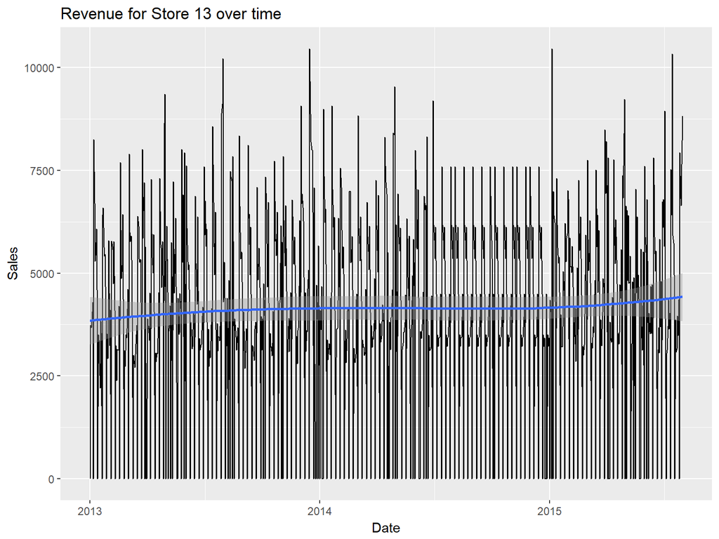

```r
store13 <- subset(train_filled_gap, Store==13)
ggplot(store13, aes(Date,Sales)) +
  geom_line() +
  geom_smooth() +
  ggtitle("Revenue for Store 13 over time")
```

Looking at the plot, we can still guess where the gap in the data was as the Sales figures are a little too regular in this period relative to other points in time. A similar statement can also be made of the plot of logSales, however, with the logarithm reducing the spikes it is a little less obvious.

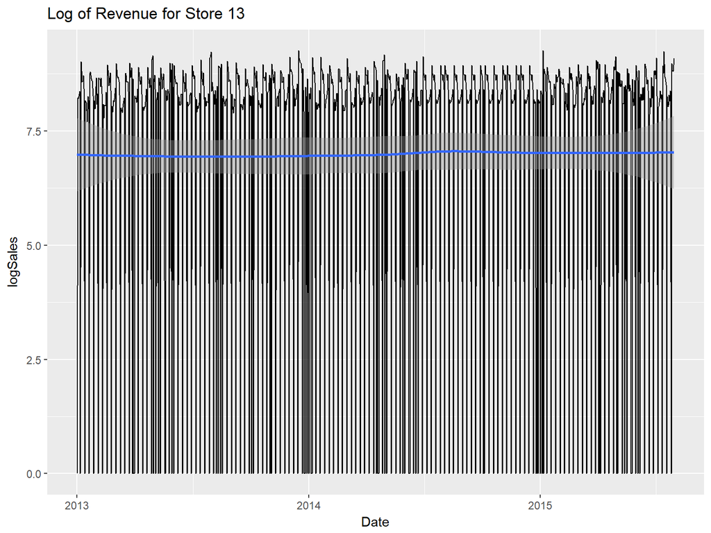

```r
ggplot(store13, aes(Date,logSales)) +
  geom_line() +
  geom_smooth() +
  ggtitle("Log of Revenue for Store 13")
```

```r
write_csv(train_filled_gap,"train_filled_gap.csv")
```

# Forecasting

The whole objective in filling the gap in the training data is to be able to use the functions in the *forecast* package to forecast sales for all stores over the entire time series. To test this, we will forecast sales for the example store we have been using.

First, we will need to load the test dataset to get information we need on store openings and promos during the period we are trying to forecast.

```r
test <- read_csv("test.csv", col_types=list(
  Id = col_integer(),
  Store = col_integer(),
  DayOfWeek= col_integer(),
  Date = col_date(),
  Open = col_integer(),
  Promo = col_integer(),
  StateHoliday = col_character(),
  SchoolHoliday = col_integer()))

store13_test <- subset(test, Store == 13)
```

For our example, we will use the Fourier ARIMA method of forecasting daily data outlined on [Rob Hyndman’s blog](http://robjhyndman.com/hyndsight/dailydata/). To use this method, we requires dummy variables to indicate holidays. For that we simply assume that if the store is closed, it is a holiday. The Promo variable also shows regular periodic behaviour with promotions recurring regularly and running for a week at a time. Thus we will include a regularisation variable for the Promo as well. Putting these together yields the following plot for the raw forecast of sales over the test period.

```r
holiday <- 1 - store13$Open
holidayf <- 1 - store13_test$Open
promo <- store13$Promo
promof <- store13_test$Promo
test_period <- max(store13_test$Date) - min(store13_test$Date) + 1

y <- ts(store13$Sales, frequency=7)
z <- fourier(ts(store13$Sales, frequency=365.25), K=5)
zf <- fourierf(ts(store13$Sales, frequency=365.25), K=5, h=test_period)
```

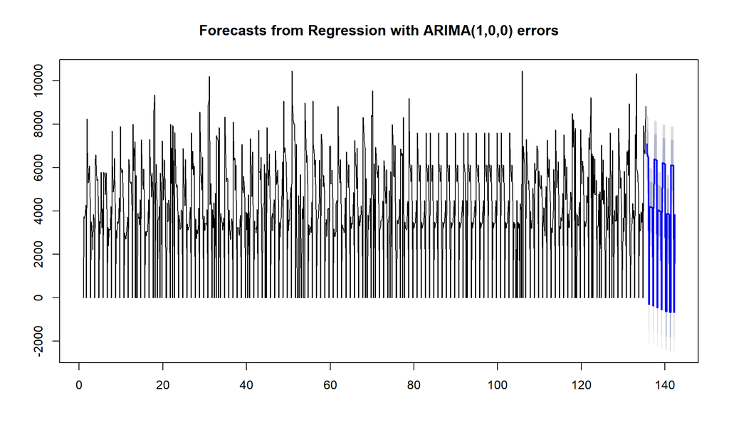

```r
fit <- auto.arima(y, xreg=cbind(z,holiday,promo), seasonal=FALSE)
fc <- forecast(fit, xreg=cbind(zf,holidayf,promof), h=test_period)
plot(fc)
```

The raw forecast shows negative revenue on days that the store should be closed but this can be easily corrected by multiplying with the vector of open days.

```r
store13_test$Sales <- fc$mean*store13_test$Open
store13_test$Sales
```

```
## Time Series:
## Start = c(135, 5)
## End = c(142, 3)
## Frequency = 7
##  [1] 7090.765 6643.804 6525.639 6491.256    0.000 4196.934 4188.901
##  [8] 4180.505 4171.515 4161.902 4151.695    0.000 4129.686 6390.130
## [15] 6378.046 6365.633 6352.953 6340.064    0.000 4041.769 4028.626
## [22] 4015.522 4002.515 3989.667 3977.033    0.000 3952.629 6213.105
## [29] 6201.863 6191.089 6180.825 6171.109    0.000    0.000 3873.436
## [36] 3866.220 3859.685 3853.847 3848.715    0.000    0.000 6109.735
## [43] 6107.445 6105.850 6104.936 6104.684    0.000 3833.941
```

We can use the same forecasting method with logSales and then use the exponential to convert the values back.

```r
y <- ts(store13$logSales, frequency=7)
z <- fourier(ts(store13$logSales, frequency=365.25), K=5)
zf <- fourierf(ts(store13$logSales, frequency=365.25), K=5, h=test_period)
```

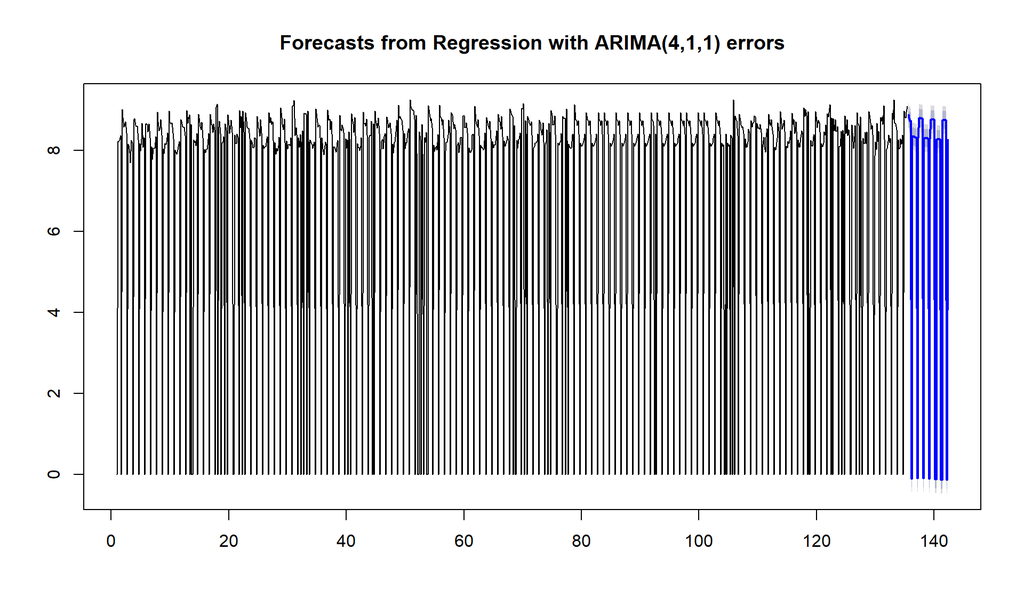

```r
fit <- auto.arima(y, xreg=cbind(z,holiday,promo), seasonal=FALSE)
fc <- forecast(fit, xreg=cbind(zf,holidayf,promof), h=test_period)
plot(fc)
```

```r
store13_test$logSales <- fc$mean*store13_test$Open
store13_test$logSales
```

```
## Time Series:
## Start = c(135, 5)
## End = c(142, 3)
## Frequency = 7
##  [1] 8.876611 8.795411 8.727301 8.732337 0.000000 8.335272 8.352407
##  [8] 8.345890 8.329371 8.315488 8.309694 0.000000 8.315180 8.797920
## [15] 8.797371 8.794393 8.790643 8.787449 0.000000 8.303537 8.302134
## [22] 8.300439 8.298362 8.296051 8.293717 0.000000 8.289432 8.767660
## [29] 8.765740 8.763835 8.761954 8.760126 0.000000 0.000000 8.275024
## [36] 8.273605 8.272294 8.271093 8.270007 0.000000 0.000000 8.747694
## [43] 8.747120 8.746678 8.746367 8.746187 0.000000 8.266017
```

Plotting the two sets of forecasts shows small variations between the two that will need to be looked at in a separate study.

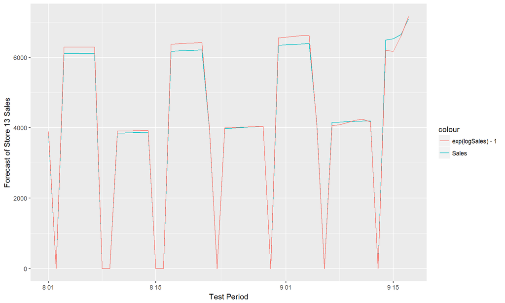

```r
ggplot(store13_test, aes(Date)) +
  geom_line(aes(y = store13_test$Sales, colour = "Sales")) +
  geom_line(aes(y = exp(store13_test$logSales)-1, colour = "exp(logSales) - 1")) +
  xlab("Test Period") +
  ylab("Forecast of Store 13 Sales")
```